# Intro practice with Differential expression analysis

### Make the model

(Treating as boilerplate. You’ll learn more about this later)

The efit object will contain the info needed to explore our differential expression results.

```r
dge <- calcNormFactors(dge, method = "TMM") #compute size normalization factors
mod_matrix <- model.matrix(~is_basal, dge$samples) #define the comparisons we want to make.
colnames(mod_matrix)[2] <- 'is_basal'
v <- voom(dge, mod_matrix) #this operates on the normalized counts data
vfit <- lmFit(v, mod_matrix) #fits the model
efit <- eBayes(vfit) #This step allows the model to 'pool' information across genes and gain statistical power
```

### Summary of results

Now we can start looking at the results of the model. This shows the overall numbers of significantly up- and down-regulated genes for each comparison. By default it uses FDR adjusted p-value of 0.05 as the threshold.

Note that the ‘intercept’ column represents the average expression among non-basal (reference) samples. So, the p-values are not meaningful (they’re testing whether the average expression is different from 0)

```r
summary(decideTests(efit))
```

```
##        (Intercept) is_basal
## Down           579     3539
## NotSig        1113     6708
## Up           12473     3918
```

### Top differentially expressed genes

The `topTable` function generates a table of top differentially expressed genes in basal vs non-basal samples. Inspect the table

```r
basal_de <- topTable(efit, coef = 'is_basal', n=Inf, genelist = dge$genes)
head(basal_de)
```

```
##        entrezgene_id mgi_symbol chromosome_name     logFC  AveExpr         t
## 269132        269132   Colgalt2               1  4.861005 3.257753  31.89397
## 353499        353499       Tmc4               7 -3.517387 7.132895 -30.39326
## 53624          53624      Cldn7              11 -5.343122 6.296762 -30.78864
## 22249          22249     Unc13b               4 -4.445240 5.664497 -30.68343
## 170643        170643     Kirrel               3  4.917726 5.296770  30.03214
## 66871          66871      Cpne8              15  4.506538 4.313707  30.03212
##             P.Value    adj.P.Val        B
## 269132 2.856533e-11 1.212922e-07 16.05298
## 353499 4.572231e-11 1.212922e-07 16.03070
## 53624  4.030517e-11 1.212922e-07 15.90008
## 22249  4.167418e-11 1.212922e-07 15.87853
## 170643 5.137649e-11 1.212922e-07 15.79625
## 66871  5.137688e-11 1.212922e-07 15.76009
```

How many genes have logFC magnitude greater than 1 and adjusted p-value less than 0.01? (HINT: you should get 3964 genes)

```r
basal_de_genes <- abs(basal_de$logFC) > 1 & basal_de$adj.P.Val < 0.01
print(table(basal_de_genes))
```

```
## basal_de_genes
## FALSE  TRUE
## 10201  3964
```

Make a new column in the `basal_de` results table called `neg_log_p` which gives the negative log10 p-value.

```r
basal_de$neg_log10_p <- -log10(basal_de$P.Value)
```

Now make a simple ‘volcano’ plot of the logFC vs neg-log-p value across genes using the `plot` function

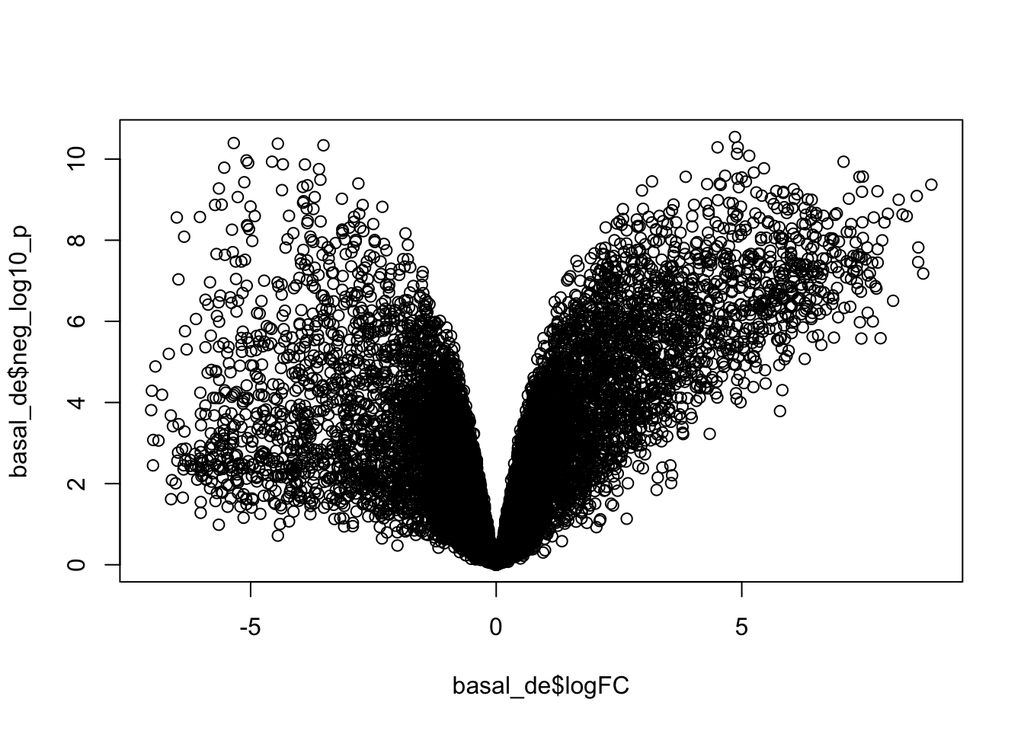

```r
plot(basal_de$logFC, basal_de$neg_log10_p)
```

Create a vector with the names of the top 10 overexpressed genes (highest magnitude logFC value) in basal compared to other cell types. HINT: the `order` function is useful for this.

```r
rank_order <- order(abs(basal_de$logFC), decreasing = TRUE)[1:10]
top_oe_genes <- basal_de[rank_order,'mgi_symbol']
```

### Saving results

Save your table of differential expression results to a ‘comma-separated’ (csv) file called ‘basal_DE_practice_res.csv’ in the ‘results’ folder in your project.

```r
write_csv(basal_de, 'results/basal_DE_practice_res.csv')
```